# Week 5 - Lectures

Vishal Gupta

3/25/2019

```r
library(dplyr)
library(rpart)
library(rpart.plot)
library(caTools)
library(ROCR)
library(randomForest)
```

## Turning Tweets into Knowledge

#### Video 5: Pre-Processing in R

Loading tweets

```r
tweets = read.csv("~/Downloads/tweets.csv", stringsAsFactors=FALSE)
str(tweets)
```

```
## 'data.frame':    1181 obs. of  2 variables:
##  $ Tweet: chr  "I have to say, Apple has by far the best customer care service I have ever received! @Apple @AppStore" "iOS 7 is so fricking smooth & beautiful!! #ThanxApple @Apple" "LOVE U @APPLE" "Thank you @apple, loving my new iPhone 5S!!!!!  #apple #iphone5S pic.twitter.com/XmHJCU4pcb" ...
##  $ Avg  : num  2 2 1.8 1.8 1.8 1.8 1.8 1.6 1.6 1.6 ...
```

Adding a `Negative` field (sentiment)

```r
tweets$Negative = as.factor(tweets$Avg <= -1)
table(tweets$Negative)
```

```
##
## FALSE  TRUE
##   999   182
```

Installing new packages

```r
#install.packages("tm")
library(tm)
#install.packages("SnowballC")
library(SnowballC)
```

Creating Corpus from Tweets

```r
corpus = Corpus(VectorSource(tweets$Tweet))
content(corpus[[1]])
```

```
## [1] "I have to say, Apple has by far the best customer care service I have ever received! @Apple @AppStore"
```

Convert tweets to lower-case

```r
corpus = tm_map(corpus, tolower)
content(corpus[[1]])
```

```
## [1] "i have to say, apple has by far the best customer care service i have ever received! @apple @appstore"
```

Remove punctuation from tweets

```r
corpus = tm_map(corpus, removePunctuation)
content(corpus[[1]])
```

```
## [1] "i have to say apple has by far the best customer care service i have ever received apple appstore"
```

corpus = tm_map(corpus, PlainTextDocument)

Removing stopwords from tweets

```r
stopwords("english")[1:10]
```

```
##  [1] "i"         "me"        "my"        "myself"    "we"
##  [6] "our"       "ours"      "ourselves" "you"       "your"
```

```r
corpus = tm_map(corpus, removeWords, c("apple", stopwords("english")))
content(corpus[1])
```

```
## [1] "   say    far  best customer care service   ever received  appstore"
```

Get word stems

```r
corpus = tm_map(corpus, stemDocument)
content(corpus[[1]])
```

```
## [1] "say far best custom care servic ever receiv appstor"
```

#### Video 6: Bag of Words in R

Creating BOW matrix

```r
frequencies = DocumentTermMatrix(corpus)
frequencies
```

```
## <<DocumentTermMatrix (documents: 1181, terms: 3289)>>
## Non-/sparse entries: 8980/3875329
## Sparsity           : 100%
## Maximal term length: 115
## Weighting          : term frequency (tf)
```

Inspecting BOW matrix for documents 1000 to 1006 & words 505 to 515

```r
inspect(frequencies[1000:1006,505:515])
```

```
## <<DocumentTermMatrix (documents: 7, terms: 11)>>
## Non-/sparse entries: 1/76
## Sparsity           : 99%
## Maximal term length: 23
## Weighting          : term frequency (tf)
## Sample             :
##       Terms
## Docs   asap courtsideassistappforio current follow idea kickbutt preinstal
##   1000    0                       0       0      0    1        0         0
##   1001    0                       0       0      0    0        0         0
##   1002    0                       0       0      0    0        0         0
##   1003    0                       0       0      0    0        0         0
##   1004    0                       0       0      0    0        0         0
##   1005    0                       0       0      0    0        0         0
##   1006    0                       0       0      0    0        0         0
##       Terms
## Docs   save ssd support
##   1000    0   0       0
##   1001    0   0       0
##   1002    0   0       0
##   1003    0   0       0
##   1004    0   0       0
##   1005    0   0       0
##   1006    0   0       0
```

Get words that occur atleast 20 times in corpus

```r
findFreqTerms(frequencies,lowfreq = 20)
```

```
##  [1] "say"                  "love"                 "iphon"
##  [4] "iphone5"              "new"                  "thank"
##  [7] "phone"                "can"                  "make"
## [10] "market"               "one"                  "will"
## [13] "cant"                 "get"                  "just"
## [16] "updat"                "fingerprint"          "iphone5c"
## [19] "store"                "time"                 "come"
## [22] "now"                  "use"                  "back"
## [25] "anyon"                "work"                 "app"
## [28] "android"              "think"                "ipad"
## [31] "well"                 "freak"                "dont"
## [34] "via"                  "better"               "like"
## [37] "pleas"                "samsung"              "want"
## [40] "batteri"              "ios7"                 "microsoft"
## [43] "itun"                 "buy"                  "releas"
## [46] "look"                 "appl"                 "need"
## [49] "googl"                "twitter"              "ipod"
## [52] "ipodplayerpromo"      "promoipodplayerpromo" "lol"
## [55] "realli"               "promo"
```

#### Quick Question

In the previous video, we showed a list of all words that appear at least 20 times in our tweets. Which of the following words appear at least 100 times?

```r
findFreqTerms(frequencies,lowfreq = 100)
```

```
## [1] "iphon" "new"   "itun"
```

Remove sparse terms from BOW matrix and create dataframe

```r
sparse = removeSparseTerms(frequencies, 0.995)
sparse
```

```
## <<DocumentTermMatrix (documents: 1181, terms: 309)>>
## Non-/sparse entries: 4669/360260
## Sparsity           : 99%
## Maximal term length: 20
## Weighting          : term frequency (tf)
```

```r
tweetsSparse = as.data.frame(as.matrix(sparse))
colnames(tweetsSparse) = make.names(colnames((tweetsSparse)))
tweetsSparse$Negative = tweets$Negative
```

Split into Test and Train set

```r
set.seed(123)
split = sample.split(tweetsSparse$Negative, SplitRatio = 0.7)
trainSparse = tweetsSparse[split==TRUE,]
testSparse = tweetsSparse[split==FALSE,]
```

Training a CART model to predict negative sentiment

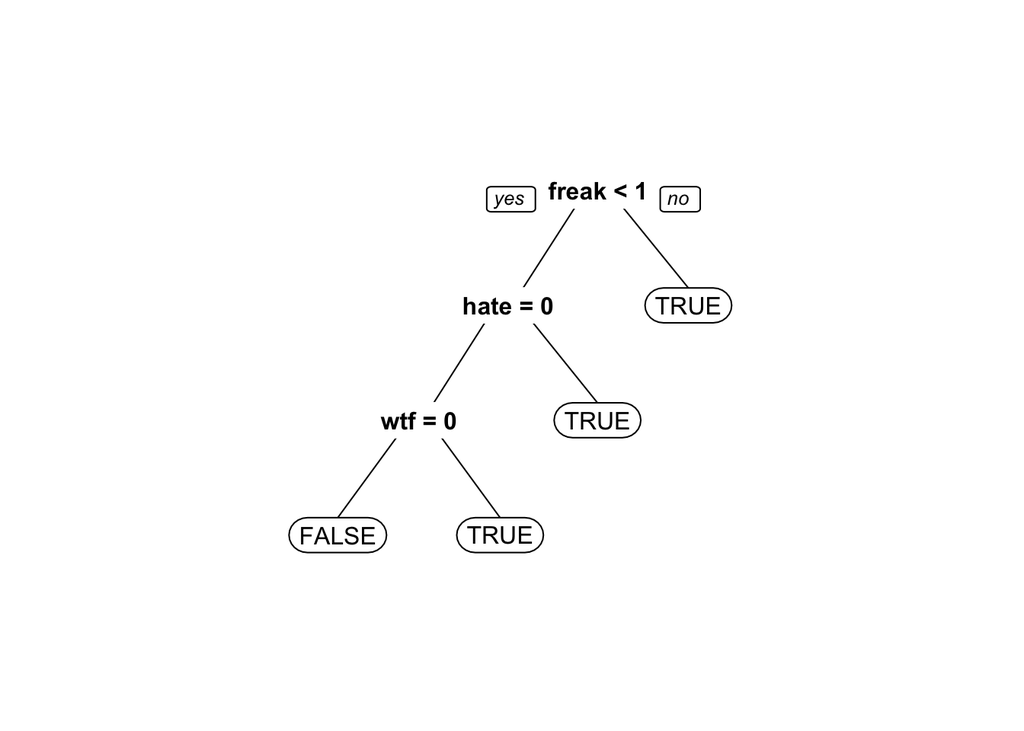

```r
tweetCART = rpart(Negative ~ ., data=trainSparse, method="class")
prp(tweetCART)
```

Evaluate the performance of CART model

```r
predictCART = predict(tweetCART, newdata=testSparse, type="class")
table(testSparse$Negative, predictCART)
```

```
##        predictCART
##         FALSE TRUE
##   FALSE   294    6
##   TRUE     37   18
```

Accuracy of CART model

```r
sum(testSparse$Negative==predictCART)/nrow(testSparse)
```

```
## [1] 0.8788732
```

Accuracy of Baseline model

```r
sum(testSparse$Negative==FALSE)/nrow(testSparse)
```

```
## [1] 0.8450704
```

Training a Random Forest model to predict negative sentiment

```r
tweetRF = randomForest(Negative ~ ., data= trainSparse)
predictRF = predict(tweetRF,testSparse)
table(predictRF,testSparse$Negative)
```

```
##
## predictRF FALSE TRUE
##     FALSE   293   32
##     TRUE      7   23
```

Accuracy of Random Forest Model

```r
sum(testSparse$Negative==predictRF)/nrow(testSparse)
```

```
## [1] 0.8901408
```

#### Quick Question

In the previous video, we used CART and Random Forest to predict sentiment. Let’s see how well logistic regression does. Build a logistic regression model (using the training set) to predict “Negative” using all of the independent variables. You may get a warning message after building your model - don’t worry (we explain what it means in the explanation).

```r
tweetLog = glm(Negative ~ ., data= trainSparse, family = binomial)
```

```
## Warning: glm.fit: fitted probabilities numerically 0 or 1 occurred
```

Now, make predictions using the logistic regression model:

```
predictions = predict(tweetLog, newdata=testSparse, type="response")
```

```r
predictions = predict(tweetLog, newdata=testSparse, type="response")
```

```
## Warning in predict.lm(object, newdata, se.fit, scale = 1, type =
## ifelse(type == : prediction from a rank-deficient fit may be misleading
```

```r
sum((predictions>0.5)==testSparse$Negative)/nrow(testSparse)
```

```
## [1] 0.8056338
```

where “tweetLog” should be the name of your logistic regression model. You might also get a warning message after this command, but don’t worry - it is due to the same problem as the previous warning message.

Build a confusion matrix (with a threshold of 0.5) and compute the accuracy of the model. What is the accuracy?